# QM 2023 Week 11: Logit and Probit Models

Oliver Rittmann

Domantas Undzėnas

November 16 | 17, 2023

## Today we will learn:

1. MLE: Logit Regression With One Covariate
2. Logit/Probit in glm
3. Quantities of Interest
4. Classification Table and Separation Plots
5. An Applied Example

In other words, the goals are to:

- Implement a MLE for a logit regression
- Use logit models with glm
- Compute meaningful quantities of interest
- Check the model fit of models with binary outcomes

```r
# The first line sets an option for the final document that can be produced from
# the .Rmd file. Don't worry about it.
knitr::opts_chunk$set(echo = TRUE,
                      collapse = TRUE,
                      out.width="\\textwidth", # for larger figures
                      attr.output = 'style="max-height: 200px"',
                      tidy = 'styler' # styles the code in the output
                      )

# The next bit is quite powerful and useful.
# First you define which packages you need for your analysis and assign it to
# the p_needed object.
p_needed <-
  c("ggplot2", "viridis", "MASS", "optimx", "scales", "foreign",
    "separationplot", "patchwork", "stargazer", "ggplotify")

# Now you check which packages are already installed on your computer.
# The function installed.packages() returns a vector with all the installed
# packages.
packages <- rownames(installed.packages())
# Then you check which of the packages you need are not installed on your
# computer yet. Essentially you compare the vector p_needed with the vector
# packages. The result of this comparison is assigned to p_to_install.
p_to_install <- p_needed[!(p_needed %in% packages)]
# If at least one element is in p_to_install you then install those missing
# packages.
if (length(p_to_install) > 0) {
  install.packages(p_to_install)
}
# Now that all packages are installed on the computer, you can load them for
# this project. Additionally the expression returns whether the packages were
# successfully loaded.
sapply(p_needed, require, character.only = TRUE)

# This is an option for stargazer tables
# It automatically adapts the output to html or latex,
# depending on whether we want a html or pdf file
stargazer_opt <- ifelse(knitr::is_latex_output(), "latex", "html")


# only relevant for ggplot2 plotting
# setting a global ggplot theme for the entire document to avoid
# setting this individually for each plot
theme_set(theme_classic() + # start with classic theme
  theme(
    plot.background = element_blank(),# remove all background
    plot.title.position = "plot", # move the plot title start slightly
    legend.position = "bottom" # by default, put legend on the bottom
  ))
```

# 1 MLE: Logit Regression With One Covariate

As usual, we start with some fake data. But this time it will be slightly different.

The first part will look familiar.

```r
# N of Population
n <- 1000

# Set our true Parameters
beta0 <- 0.25
beta1 <- -0.8

# Randomly draw an Independent Variable
set.seed(2023)
X <- rnorm(n, 0, 1)
```

Now we need some additional lines.

We generate `p` (aka $\pi$ on slide 10) via the *logistic response function*:

$$\pi_i = \frac{\exp(X_i\beta)}{1+\exp(X_i\beta)} =
\dfrac{\overbrace{\exp(\mu_i)}^{\text{always greater than
0}}}{\underbrace{1 + \exp(\mu_i)}_{\text{1 + "always greater than
0"}}} \Rightarrow 0 < \pi_i < 1$$

Here `mu` is the linear predictor. Together, the linear predictor and the response function constitute the *systematic component* of the model. By using the *logistic response function*, we are ensuring that with any value of $X$ or $\beta$, the systematic component is reparametarized to be between 0 and 1.

```r
mu <- beta0 + beta1 * X

p <- exp(mu) / (1 + exp(mu))

# we achieve the same with the following code:
p <- plogis(mu)
```

Let’s quickly plot what we just did:

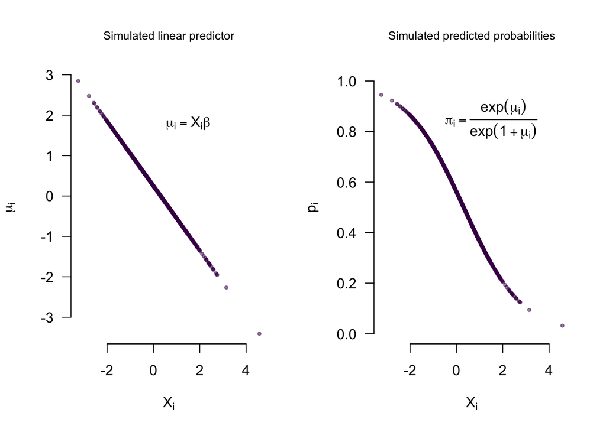

```r
par(mfrow = c(1, 2))

# Systematic component: linear predictor
plot(
  x = X,
  y = mu,
  pch = 19,
  cex = 0.5,
  col = viridis(1, 0.5),
  main = "Simulated linear predictor",
  font.main = 1,
  cex.main = 0.8,
  ylab = expression(mu[i]),
  xlab = expression(X[i]),
  las = 1,
  bty = "n"
)
text(
  x = 1.5,
  y = 1.8,
  labels = expression(mu[i] == X[i] * beta)
)

# Systematic component: predicted probabilities
plot(
  x = X,
  y = p,
  pch = 19,
  cex = 0.5,
  col = viridis(1, 0.5),
  ylim = c(0, 1),
  main = "Simulated predicted probabilities",
  font.main = 1,
  cex.main = 0.8,
  ylab = expression(p[i]),
  xlab = expression(X[i]),
  las = 1,
  bty = "n"
)
text(
  x = 1.5,
  y = 0.85,
  labels = expression(pi[i] == frac(exp(mu[i]), exp(1 + mu[i])))
)
```

As we observe only 0 or 1, we draw from a *Bernoulli* distribution (the *stochastic component* of the model) with p = p ($\pi$). Recall that in R, we take draws from Bernoulli by working with its more general form, the *Binomial* distribution, but specify the `size = 1`, i.e. that we only take one draw from this distribution:

```r
Y <- rbinom(n, 1, p)
```

Let’s add this step to the plot above:

## Base R

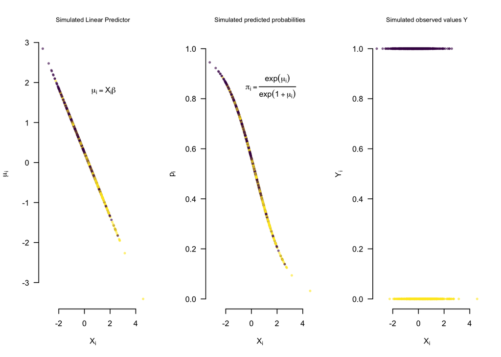

```r
par(mfrow = c(1, 3))

# Systematic component: LP (unobserved in reality)
plot(
  x = X,
  y = mu,
  pch = 19,
  cex = 0.5,
  col = ifelse(Y == 1, viridis(2, 0.5)[1], viridis(2, 0.5)[2]),
  main = "Simulated Linear Predictor",
  font.main = 1,
  cex.main = 0.8,
  ylab = expression(mu[i]),
  xlab = expression(X[i]),
  las = 1,
  bty = "n"
)
text(
  x = 1.5,
  y = 1.8,
  labels = expression(mu[i] == X[i] * beta)
)

# Systematic component: predicted probabilities (unobserved in reality)
plot(
  x = X,
  y = p,
  pch = 19,
  cex = 0.5,
  ylim = c(0, 1),
  col = ifelse(Y == 1, viridis(2, 0.5)[1], viridis(2, 0.5)[2]),
  main = "Simulated predicted probabilities",
  font.main = 1,
  cex.main = 0.8,
  ylab = expression(p[i]),
  xlab = expression(X[i]),
  las = 1,
  bty = "n"
)
text(
  x = 1.5,
  y = 0.85,
  labels = expression(pi[i] == frac(exp(mu[i]), exp(1 + mu[i])))
)

# observed values
plot(
  x = X,
  y = Y,
  pch = 19,
  cex = 0.5,
  col = ifelse(Y == 1, viridis(2, 0.5)[1], viridis(2, 0.5)[2]),
  main = "Simulated observed values Y",
  font.main = 1,
  cex.main = 0.8,
  ylab = expression(Y[i]),
  xlab = expression(X[i]),
  las = 1,
  bty = "n"
)
```

Now we want to estimate a logit model, i.e., to get back from the observed probabilities $Y$ and the values of $X$ to the coefficients $\beta$ and probabilities $\pi$.

## ggplot2

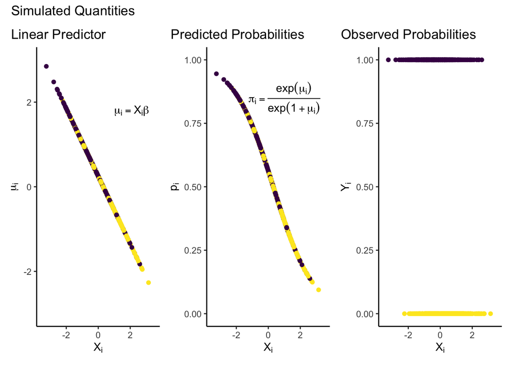

```r
# Systematic component: LP
syst <- ggplot() +
  scale_y_continuous(limits = c(-3, 3)) +
  scale_x_continuous(limits = c(-3.5, 3.5)) +
  geom_point(aes(
    x = X, y = mu,
    color = Y
  )) +
  labs(
    x = expression(X[i]),
    y = expression(mu[i]),
    title = "Linear Predictor"
  ) +
  annotate("text",
    label = expression(mu[i] == X[i] * beta),
    x = 1, y = 1.8,
    hjust = 0
  )

# Systematic component: predicted probabilities
pps <- ggplot() +
  scale_y_continuous(limits = c(0, 1)) +
  scale_x_continuous(limits = c(-3.5, 3.5)) +
  geom_point(aes(
    x = X, y = p,
    color = Y
  )) +
  labs(
    x = expression(X[i]),
    y = expression(p[i]),
    title = "Predicted Probabilities"
  ) +
  annotate("text",
    label = expression(pi[i] == frac(exp(mu[i]), exp(1 + mu[i]))),
    x = 1, y = 0.85
  )

# observed values
yhat <- ggplot() +
  scale_y_continuous(limits = c(0, 1)) +
  scale_x_continuous(limits = c(-3.5, 3.5)) +
  geom_point(aes(
    x = X, y = Y,
    color = Y
  )) +
  labs(
    x = expression(X[i]),
    y = expression(Y[i]),
    title = "Observed Probabilities"
  )

syst + pps + yhat +
  plot_annotation(title = "Simulated Quantities") &
  scale_color_viridis(direction = -1) & theme(legend.position = "none")
```

Now we want to estimate a logit model, i.e., to get back from the observed probabilities $Y$ and the values of $X$ to the coefficients $\beta$ and probabilities $\pi$.

# 2 Logit MLE

We start by writing our own logistic response function in `R`:
$$\pi =
\dfrac{\overbrace{\exp(x)}^{\text{always greater than 0}}}{\underbrace{1
+ \exp(x)}_{\text{1 + "always greater than 0"}}} \Rightarrow 0
< \pi < 1$$
.

```r
l_response <- function(x) {
  exp(x) / (1 + exp(x))
}
```

Check if your function works:

```r
head(l_response(beta0 + beta1 * X))
```

## 2.1 Set up the (log-)likelihood function

As we want to estimate $\beta_0$ and $\beta_1$ using MLE, we need to set up a (log-)likelihood function.

For this, we translate the Log-likelihood of the Logit model from slide 14 to `R`.

$$\ell(\beta|y, X) =
\sum_{i=1}^{n} [y_i \cdot \log
\frac{\exp(X_{i}\beta)}{1+\exp(X_{i}\beta)} +
(1-y_i) \cdot \log(1-\frac{\exp(X_{i}\beta)}{1+\exp(X_{i}\beta)})]$$

This looks messier than it is.

What happens to the log-likelihood function when $y_i = 0$?

$$y_i \cdot \log \frac{\exp(X_{i}\beta)}{1+\exp(X_{i}\beta)} +
(1-y_i) \cdot \log(1-\frac{\exp(X_{i}\beta)}{1+\exp(X_{i}\beta)})
\\=
\underbrace{0 \cdot \log
\frac{\exp(X_{i}\beta)}{1+\exp(X_{i}\beta)}}_{\text{cancels out}} +
\underbrace{(1-0) \cdot
\log(1-\frac{\exp(X_{i}\beta)}{1+\exp(X_{i}\beta)})}_{\text{stays}} \\=
\log(1-\frac{\exp(X_{i}\beta)}{1+\exp(X_{i}\beta)})$$

The opposite is true when $y_i = 1$:

$$y_i \cdot \log \frac{\exp(X_{i}\beta)}{1+\exp(X_{i}\beta)} +
(1-y_i) \cdot \log(1-\frac{\exp(X_{i}\beta)}{1+\exp(X_{i}\beta)})
\\=
\underbrace{1 \cdot \log
\frac{\exp(X_{i}\beta)}{1+\exp(X_{i}\beta)}}_{\text{stays}} +
\underbrace{(1-1) \cdot
\log(1-\frac{\exp(X_{i}\beta)}{1+\exp(X_{i}\beta)})}_{\text{cancels
out}} \\=
\log(\frac{\exp(X_{i}\beta)}{1+\exp(X_{i}\beta)})$$
Depending on the value we observe, $y_i = 0$ or $y_i = 1$, we receive these reduced parts of the log-likelihood function for each observation and sum across them.

Now we can translate this into R.

Remember that we already have the response function $\dfrac{\exp(X_{i}\beta)}{1+\exp(X_{i}\beta)}$ implemented as `l_response()`.

```r
logit_ll <- function(X, Y, theta) {
  beta0 <- theta[1]
  beta1 <- theta[2]

  mu <- theta[1] + theta[2] * X

  logl <- sum(Y * log(l_response(mu)) + (1 - Y) * log(1 - l_response(mu)))

  return(logl)
}
```

Thanks to this reparameterization of the linear predictor `mu` with the `l_response`, we can estimate the `theta` as unbounded, yet still ensuring that the predicted probabilities will be within the range of 0 and 1.

Now we maximize it numerically with the help of `optimx`.

```r
# Set Starting Values
stval <- c(0, 0) # 2 values of theta -> 2 starting values

# Optimize
res <- optimx(
  par = stval, # start values
  fn = logit_ll, # log-likelihood function
  Y = Y,
  X = X,
  control = list(maximize = T)
)
## Maximizing -- use negfn and neggr
## Warning in max(logpar): no non-missing arguments to max; returning -Inf
## Warning in min(logpar): no non-missing arguments to min; returning Inf
res
##                    p1         p2     value fevals gevals niter convcode kkt1
## Nelder-Mead 0.1585808 -0.7317630 -632.8729     59     NA    NA        0 TRUE
## BFGS        0.1586419 -0.7318319 -632.8729     35     10    NA        0 TRUE
##             kkt2 xtime
## Nelder-Mead TRUE 0.008
## BFGS        TRUE 0.004
```

# 3 Logit/Probit in glm

Luckily, this is all implemented in `R` already.

Have a look at the documentation of `glm`.

```r
?glm
```

Let’s make use of it:

```r
m0 <- glm(Y ~ X,
  family = binomial(link = logit)
)

summary(m0)
```

```
##
## Call:
## glm(formula = Y ~ X, family = binomial(link = logit))
##
## Coefficients:
##             Estimate Std. Error z value Pr(>|z|)
## (Intercept)  0.15864    0.06722   2.360   0.0183 *
## X           -0.73183    0.07424  -9.858   <2e-16 ***
## ---
## Signif. codes:  0 '***' 0.001 '**' 0.01 '*' 0.05 '.' 0.1 ' ' 1
##
## (Dispersion parameter for binomial family taken to be 1)
##
##     Null deviance: 1379.9  on 999  degrees of freedom
## Residual deviance: 1265.7  on 998  degrees of freedom
## AIC: 1269.7
##
## Number of Fisher Scoring iterations: 4
```

With `glm` we can also easily implement a probit model:

```r
m0_probit <- glm(Y ~ X,
  family = binomial(link = probit)
)

m0_probit$coefficients
## (Intercept)           X
##  0.09735092 -0.44814068
```

> **Why do the coefficients differ for logit and probit models?** (Slide 15 might help.)

### Predicted Probabilities from Logit and Probit

The predicted probability from the **logit** model would be:

```r
head(l_response(coef(m0)[1] + coef(m0)[2] * X))
## [1] 0.5547688 0.7064058 0.8221344 0.5731876 0.6507294 0.3453283
```

The predicted probability from the **probit** model would be:

```r
head(pnorm(coef(m0_probit)[1] + coef(m0_probit)[2] * X))
## [1] 0.5536538 0.7046590 0.8257865 0.5717259 0.6484880 0.3477213
```

# 4 Quantities of Interest

The coefficients of logit and (even more so) probit models are really hard to interpret beyond their sign. Now our simulation approach, to get meaningful quantities of interest, becomes really helpful.

Let’s start with plotting expected probabilities of our fake data model.

## 4.1 Simulate Parameters

Remember the steps?

Steps for simulating parameters (Estimation Uncertainty):

1. Get the coefficients from the regression (`beta_hat`).
2. Get the variance-covariance matrix (`V_hat`).
3. Set up a multivariate normal distribution `N(beta_hat, V_hat)`.
4. Draw from the distribution `nsim` times.

```r
# 1. get the coefficients
beta_hat <- coef(m0)

# 2. Get the variance-covariance matrix
V_hat <- vcov(m0)

# 3. Set up a multivariate normal distribution N(beta_hat, V_hat)
# 4. Draw from the distribution nsim times
nsim <- 10000
S <- mvrnorm(
  n = nsim,
  mu = beta_hat,
  Sigma = V_hat
)
```

## 4.2 Calculate Expected Values

*Next step*: set up an interesting scenarios and calculate expected values.

```r
# we simulate over a sequence of x-values
seq_X <- seq(min(X), max(X), length.out = 100)
scenario <- cbind(1, seq_X)

# linear predictor
Xbeta <- S %*% t(scenario)

dim(Xbeta)
## [1] 10000   100
```

So far there is nothing new compared to OLS simulation!

*Now comes the difference:*

To get expected values for $p$ (aka predicted probabilities), we need to plug in the $X_i\beta$ (`Xbeta`) values into the response function to get **simulated probabilities**.

```r
p_sim <- (exp(Xbeta)) / (1 + exp(Xbeta))

# we can also use our own function:
p_sim <- l_response(Xbeta)

# or the build-in R-function for logistic distribution function (CDF):
p_sim <- plogis(Xbeta) # aka inverse logit

dim(p_sim)
## [1] 10000   100
```

As before, we also want means and quantiles of our quantities of interest.

```r
p_mean <- apply(p_sim, 2, mean)
p_qu <- t(apply(p_sim, 2, quantile, prob = c(0.025, 0.975)))
```

### Base R

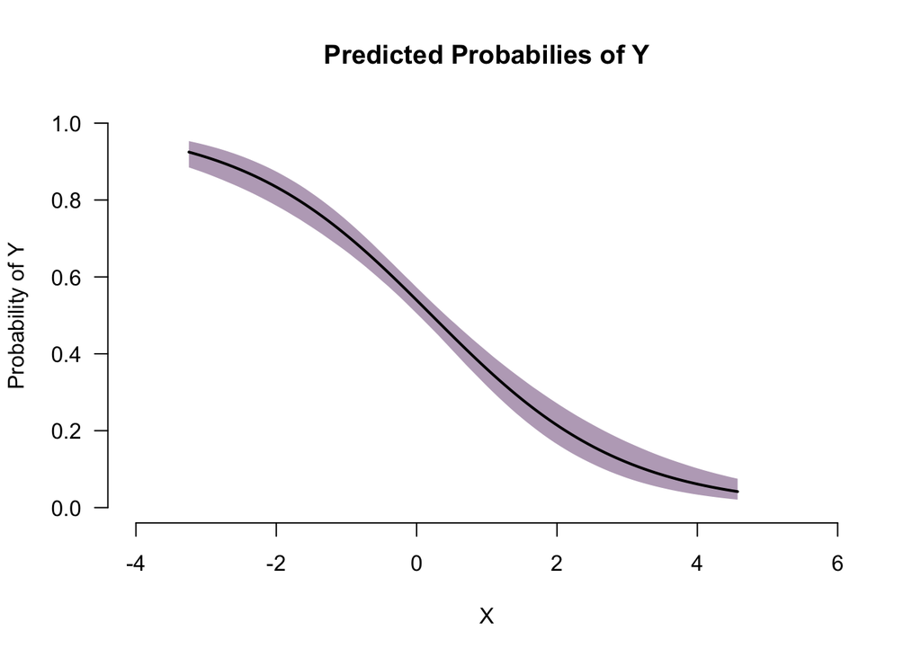

```r
plot(
  x = seq_X,
  y = p_mean,
  ylim = c(0, 1),
  xlim = range(pretty(seq_X)),
  type = "n",
  main = "Predicted Probabilies of Y",
  ylab = "Probability of Y",
  xlab = "X",
  bty = "n",
  las = 1
)

# plot uncertainty with a polygon
polygon(
  x = c(rev(seq_X), seq_X),
  y = c(rev(p_qu[, 2]), p_qu[, 1]),
  col = viridis(1, 0.4),
  border = NA
)

# and a line
lines(
  x = seq_X,
  y = p_mean,
  lwd = 2
)
```

Remember that we know the true data generating process (because we simulated the data). This means that we also know the true probability of Y for each observation. Let’s see how well our estimation (and simulation) worked:

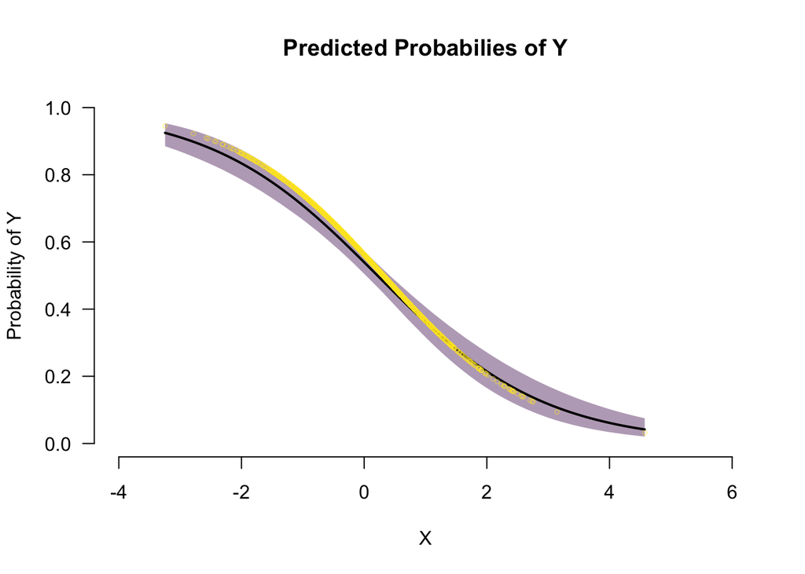

```r
plot(
  x = seq_X,
  y = p_mean,
  ylim = c(0, 1),
  xlim = range(pretty(seq_X)),
  type = "n",
  main = "Predicted Probabilies of Y",
  ylab = "Probability of Y",
  xlab = "X",
  bty = "n",
  las = 1
)

# plot uncertainty with a polygon
polygon(
  x = c(rev(seq_X), seq_X),
  y = c(rev(p_qu[, 2]), p_qu[, 1]),
  col = viridis(2, 0.4)[1],
  border = NA
)

# and a line
lines(
  x = seq_X,
  y = p_mean,
  lwd = 2
)

# we add the "true" probabilities
# note that these are unobserved in the real world
points(
  x = X,
  y = p,
  pch = 1,
  cex = 0.5,
  ylim = c(0, 1),
  col = viridis(2, 0.4)[2]
)
```

### ggplot2

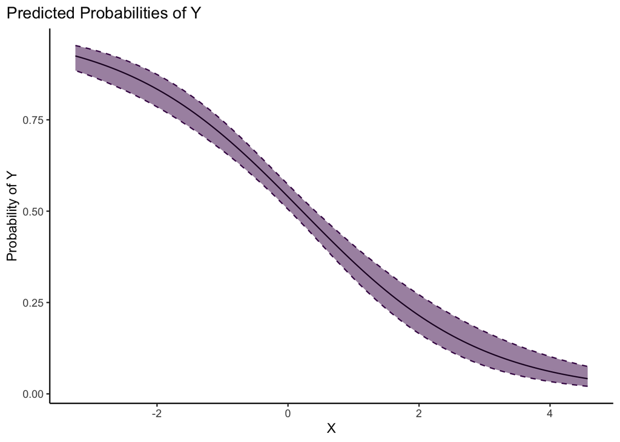

```r
# data frame for predicted probabilities and CI
plot_df <- data.frame(
  "p_mean" = p_mean,
  "ci_lo" = p_qu[, 1],
  "ci_hi" = p_qu[, 2]
)
plot_df$seq_X <- seq_X

# plot
pp <- ggplot(data = plot_df, aes(x = seq_X, y = p_mean)) +
  geom_line() +
  geom_ribbon(
    aes(ymin = ci_lo, ymax = ci_hi),
    fill = viridis(1, 0.5), # add color for filling
    color = viridis(1), # add color for lines
    linetype = "dashed" # make lines dashed
  ) +
  labs(
    x = "X",
    y = "Probability of Y",
    title = "Predicted Probabilities of Y"
  )
pp
```

Remember that we know the true data generating process (because we simulated the data). This means that we also know the true probability of Y for each observation. Let’s see how well our estimation (and simulation) worked:

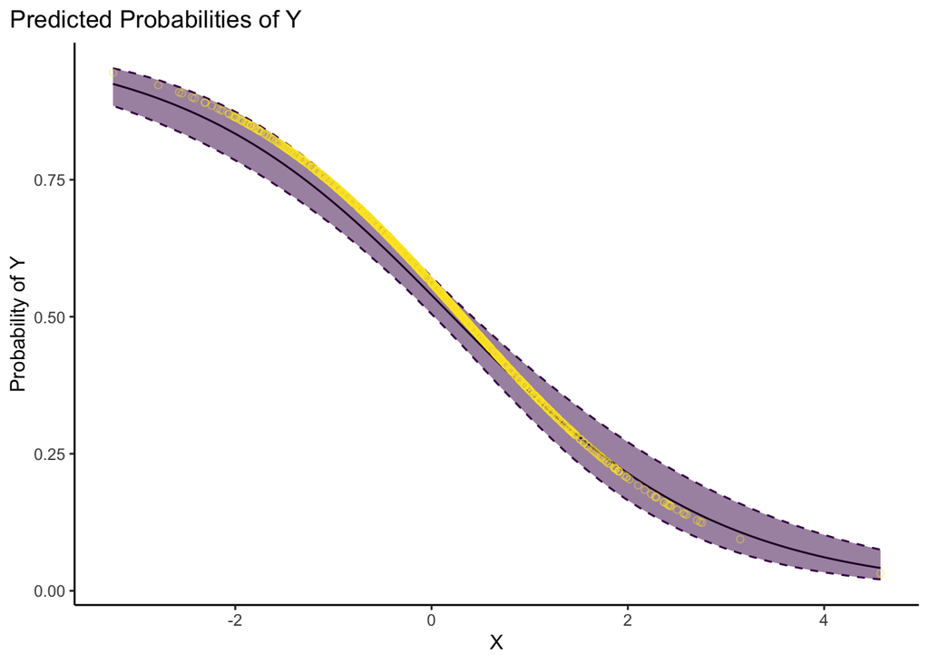

```r
fake_data <- data.frame(X, p)
pp + geom_point(
  data = fake_data,
  aes(x = X, y = p),
  shape = 1,
  color = viridis(2, 0.4)[2]
)
```

# 5 Classification Tables and Separation Plots

How can we check how good our logit model actually is?

## 5.1 Classification Tables

An easy test is to cross-tabulate observed and predicted values of y. For this we classify the predicted probabilities as either 0 or 1. This of course depends on some cut-point. Usually we take a cutoff point of 0.5.

Let’s do this for our model: `m0$fitted.values > 0.5` will generate the logical values for whether the fitted value is above or below the threshold `TRUE` and `FALSE`, and we will multiply them by `*1` to make `TRUE` equal 1 and `FALSE` equal zero.

```r
table(
  observed = Y,
  predicted = (m0$fitted.values > 0.5) * 1
) # or simply round(m0$fitted.values)
##         predicted
## observed   0   1
##        0 256 204
##        1 155 385
```

> *How many correctly predicted?* *How many falsely predicted?*

Let’s make a classification table and calculate the percentage of correctly predicted (aka accuracy) cases (*PCP*; see slide 25).

```r
class_table <- table(observed = Y, predicted = (m0$fitted.values > 0.5) * 1)
class_table
##         predicted
## observed   0   1
##        0 256 204
##        1 155 385

pcp <- sum(diag(class_table)) / sum(class_table)
pcp
## [1] 0.641
```

## 5.2 Separation Plots

Another very good way to asses model fit are separation plots.

Let’s install the package `separationlpot` to get started (already done).

Separation plot is a method to visually inspect the fit of a binary model. In this plot, the dark and light panels correspond to the actual instances of the events $(y_i = 1)$ and nonevents $(y_i = 0)$, respectively. Construction of the separation plot begins by simply rearranging the observations such that the fitted values, i.e. the predicted probabilities $\pi_i$ are presented in ascending order (you can spot it on the black line on the plot). Then one notes whether each of these observations corresponds to an actual instance of the event $(y_i = 1)$ or a nonevent $(y_i = 0)$. These are depicted with the color panels mentioned above. The more nonevents are on the left side and the more events are on the right side, the better the model fit.

Greenhill, Ward, and Sacks (2011) explain this in more detail:

> A model with no predictive power-i.e., one whose outcomes can be approximated by a random coin toss—would generate an even distribution of 0s and 1s along the column on the right-hand side. On the other hand, a model with perfect predictive power would produce a complete separation of the 0s and 1s in the right-hand column: low fitted values would always turn out to be associated with actual instances of peace (0s), whereas high fitted values would always be associated with actual instances of war (1s).

[figure not shown]

The dark line, the respective $\pi_i$, allows us to judge whether the overall degree of separation between events and nonevents is associated with sharp differences in predicted probabilities, or more modest differences.

Another quantity of interest is the *expected number of total events* predicted by the model. We can calculate this by simply adding up the predicted probabilities across all observations and rounding the value. This quantity, depicted with a small black triangle on the plot, allows to see how the total number of events predicted by the model compares to the actual number of events in the data.

This is what the separation plot for our fake data would look like:

### Base R

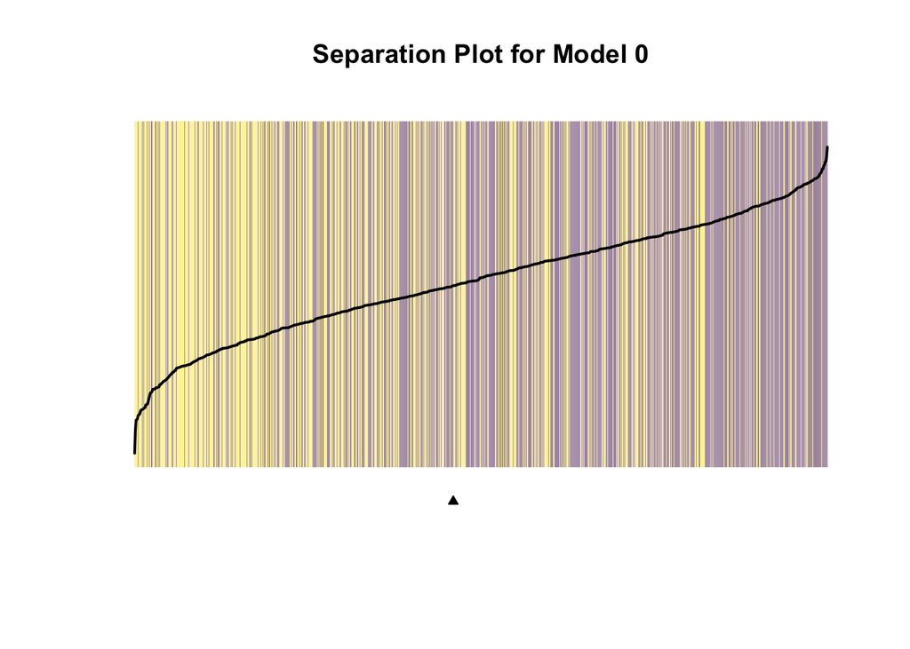

```r
separationplot(
  pred = m0$fitted,
  actual = Y,
  line = TRUE,
  heading = "Separation Plot for Model 0",
  show.expected = T,
  col0 = viridis(2, alpha = 0.5)[2],
  col1 = viridis(2, alpha = 0.5)[1],
  lwd2 = 2,
  height = 2,
  newplot = F
)
```

If you want to know more about Separation Plots and see more examples of using them, you should read the paper by Greenhill, Ward, and Sacks (2011).

### ggplot2

In case you want to keep all plots as `ggplot2` objects for some reason (say to keep the figure fonts uniform across the paper), you can transform these base R objects into `ggplot2` kind with `ggplotify` package:

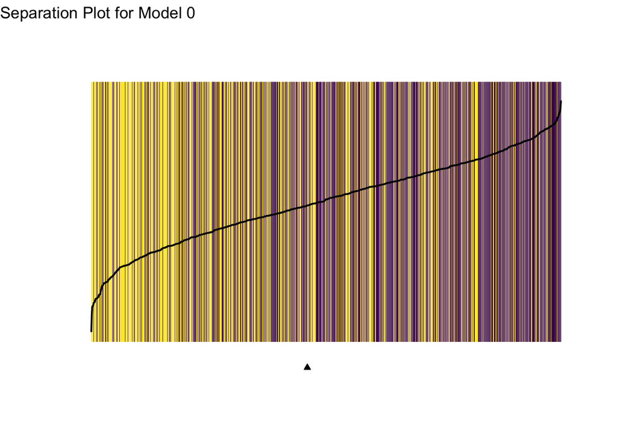

```r
as.ggplot(~ separationplot(
  pred = m0$fitted,
  actual = Y,
  line = TRUE,
  show.expected = T,
  col0 = viridis(2)[2],
  col1 = viridis(2)[1],
  lwd2 = 2,
  newplot = F
)) +
  labs(title = "Separation Plot for Model 0")
```

# 6 An Applied Example: Fearon and Laitin 2003: Ethnicity, Insurgency, and Civil War

Let’s have a look at some real data!

We will work with the Fearon and Laitin (2003) dataset. You can find the respective paper, “Ethnicity, Insurgency, and Civil War”, [here](https://www.cambridge.org/core/journals/american-political-science-review/article/ethnicity-insurgency-and-civil-war/B1D5D0E7C782483C5D7E102A61AD6605). It was published 2003 in the *American Political Science Review* and is cited more than 11.000 times!

Main finding of that study: “The factors that explain which countries have been at risk for civil war **are not** their *ethnic or religious characteristics* **but rather** the *conditions that favor insurgency*. These include poverty […], political instability, rough terrain, and large populations.”

First, we estimate the effect of log mountains (`log_mountain`), a measure of “rough terrain”, on onset of civil war (`civilwar`) using `optimx` and the functions from above.

We start with a simple bivariate model.

```r
df <- read.dta("raw-data/fearon.dta")
stargazer(df, type = stargazer_opt)
```

| Statistic | N | Mean | St. Dev. | Min | Max |
| --- | --- | --- | --- | --- | --- |
| civilwar | 6,191 | 0.017 | 0.129 | 0 | 1 |
| ethnicwar | 6,191 | 0.011 | 0.106 | 0 | 1 |
| priorwar | 6,191 | 0.133 | 0.340 | 0 | 1 |
| gdp_lagged | 6,191 | 3.609 | 4.327 | 0.048 | 53.901 |
| log_population | 6,191 | 9.078 | 1.456 | 5.403 | 14.029 |
| log_mountain | 6,191 | 2.177 | 1.409 | 0.000 | 4.557 |
| noncontiguous | 6,191 | 0.178 | 0.383 | 0 | 1 |
| oil | 6,191 | 0.128 | 0.334 | 0 | 1 |
| newstate | 6,191 | 0.026 | 0.160 | 0 | 1 |
| instability | 6,191 | 0.146 | 0.353 | 0 | 1 |
| democracy1 | 6,191 | -0.479 | 7.555 | -10 | 10 |
| ethnicfrac | 6,191 | 0.388 | 0.286 | 0.001 | 0.925 |
| relifrac | 6,191 | 0.366 | 0.219 | 0.000 | 0.783 |
| anocracy | 6,191 | 0.218 | 0.413 | 0 | 1 |
| democracy2 | 6,191 | 0.335 | 0.472 | 0 | 1 |

```r
res2 <- optimx(stval,
  logit_ll,
  Y = df$civilwar,
  X = df$log_mountain,
  control = list(maximize = T)
)
```

```
## Maximizing -- use negfn and neggr
```

```r
res2
```

```
##                    p1        p2     value fevals gevals niter convcode kkt1
## Nelder-Mead -4.740625 0.2764533 -521.1480     77     NA    NA        0 TRUE
## BFGS        -4.742026 0.2765875 -521.1479     40     16    NA        0 TRUE
##             kkt2 xtime
## Nelder-Mead TRUE 0.020
## BFGS        TRUE 0.029
```

Now we want to fit the same logit regression as above, but this time using `glm`:

```r
m1 <- glm(civilwar ~ log_mountain,
  data = df,
  family = binomial(link = logit)
)
```

Let’s see how we did and compare the results to our likelihood function.

```r
m1$coefficients
##  (Intercept) log_mountain
##   -4.7412093    0.2763476

res2[1:2, 1:2]
##                    p1        p2
## Nelder-Mead -4.740625 0.2764533
## BFGS        -4.742026 0.2765875
```

## 6.1 One of the published Fearon/Laitin Models

We load the data and omit all observations with missing values.

```r
df <- read.dta("raw-data/fearon_rep.dta")
summary(df)
```

```
##     civilwar         ethnicwar         priorwar        gdp_lagged
##  Min.   :0.00000   Min.   :0.0000   Min.   :0.0000   Min.   : 0.048
##  1st Qu.:0.00000   1st Qu.:0.0000   1st Qu.:0.0000   1st Qu.: 0.930
##  Median :0.00000   Median :0.0000   Median :0.0000   Median : 1.995
##  Mean   :0.01664   Mean   :0.0112   Mean   :0.1346   Mean   : 3.651
##  3rd Qu.:0.00000   3rd Qu.:0.0000   3rd Qu.:0.0000   3rd Qu.: 4.484
##  Max.   :1.00000   Max.   :1.0000   Max.   :1.0000   Max.   :66.735
##  NA's   :1         NA's   :1                         NA's   :237
##  log_population    log_mountain    noncontiguous         oil
##  Min.   : 5.403   Min.   :0.0000   Min.   :0.0000   Min.   :0.0000
##  1st Qu.: 8.076   1st Qu.:0.9933   1st Qu.:0.0000   1st Qu.:0.0000
##  Median : 9.004   Median :2.4248   Median :0.0000   Median :0.0000
##  Mean   : 9.063   Mean   :2.1767   Mean   :0.1734   Mean   :0.1295
##  3rd Qu.: 9.933   3rd Qu.:3.3393   3rd Qu.:0.0000   3rd Qu.:0.0000
##  Max.   :14.029   Max.   :4.5570   Max.   :1.0000   Max.   :1.0000
##  NA's   :177
##     newstate        instability       democracy1         ethnicfrac
##  Min.   :0.00000   Min.   :0.0000   Min.   :-10.0000   Min.   :0.0010
##  1st Qu.:0.00000   1st Qu.:0.0000   1st Qu.: -7.0000   1st Qu.:0.1073
##  Median :0.00000   Median :0.0000   Median : -3.0000   Median :0.3255
##  Mean   :0.02965   Mean   :0.1465   Mean   : -0.4799   Mean   :0.3854
##  3rd Qu.:0.00000   3rd Qu.:0.0000   3rd Qu.:  8.0000   3rd Qu.:0.6637
##  Max.   :1.00000   Max.   :1.0000   Max.   : 10.0000   Max.   :0.9250
##                    NA's   :14       NA's   :69
##     relifrac         anocracy        democracy2
##  Min.   :0.0000   Min.   :0.0000   Min.   :0.0000
##  1st Qu.:0.1818   1st Qu.:0.0000   1st Qu.:0.0000
##  Median :0.3576   Median :0.0000   Median :0.0000
##  Mean   :0.3674   Mean   :0.2256   Mean   :0.3322
##  3rd Qu.:0.5566   3rd Qu.:0.0000   3rd Qu.:1.0000
##  Max.   :0.7828   Max.   :1.0000   Max.   :1.0000
##                   NA's   :69       NA's   :69
```

```r
df2 <- na.omit(df)
summary(df2)
```

```
##     civilwar        ethnicwar          priorwar        gdp_lagged
##  Min.   :0.0000   Min.   :0.00000   Min.   :0.0000   Min.   : 0.0480
##  1st Qu.:0.0000   1st Qu.:0.00000   1st Qu.:0.0000   1st Qu.: 0.9295
##  Median :0.0000   Median :0.00000   Median :0.0000   Median : 1.9980
##  Mean   :0.0168   Mean   :0.01131   Mean   :0.1331   Mean   : 3.6085
##  3rd Qu.:0.0000   3rd Qu.:0.00000   3rd Qu.:0.0000   3rd Qu.: 4.4690
##  Max.   :1.0000   Max.   :1.00000   Max.   :1.0000   Max.   :53.9010
##  log_population    log_mountain    noncontiguous         oil
##  Min.   : 5.403   Min.   :0.0000   Min.   :0.0000   Min.   :0.0000
##  1st Qu.: 8.091   1st Qu.:0.9933   1st Qu.:0.0000   1st Qu.:0.0000
##  Median : 9.018   Median :2.4248   Median :0.0000   Median :0.0000
##  Mean   : 9.078   Mean   :2.1772   Mean   :0.1782   Mean   :0.1279
##  3rd Qu.: 9.946   3rd Qu.:3.3776   3rd Qu.:0.0000   3rd Qu.:0.0000
##  Max.   :14.029   Max.   :4.5570   Max.   :1.0000   Max.   :1.0000
##     newstate        instability      democracy1         ethnicfrac
##  Min.   :0.00000   Min.   :0.000   Min.   :-10.0000   Min.   :0.0010
##  1st Qu.:0.00000   1st Qu.:0.000   1st Qu.: -7.0000   1st Qu.:0.1073
##  Median :0.00000   Median :0.000   Median : -3.0000   Median :0.3331
##  Mean   :0.02617   Mean   :0.146   Mean   : -0.4786   Mean   :0.3880
##  3rd Qu.:0.00000   3rd Qu.:0.000   3rd Qu.:  8.0000   3rd Qu.:0.6666
##  Max.   :1.00000   Max.   :1.000   Max.   : 10.0000   Max.   :0.9250
##     relifrac         anocracy        democracy2
##  Min.   :0.0000   Min.   :0.0000   Min.   :0.000
##  1st Qu.:0.1818   1st Qu.:0.0000   1st Qu.:0.000
##  Median :0.3508   Median :0.0000   Median :0.000
##  Mean   :0.3662   Mean   :0.2184   Mean   :0.335
##  3rd Qu.:0.5566   3rd Qu.:0.0000   3rd Qu.:1.000
##  Max.   :0.7828   Max.   :1.0000   Max.   :1.000
```

Let’s estimate the model:

```r
m_fearon1 <- glm(
  civilwar ~
    priorwar +
    gdp_lagged +
    log_population +
    log_mountain +
    noncontiguous +
    oil +
    newstate +
    instability +
    democracy1 +
    ethnicfrac +
    relifrac,
  data = df,
  family = binomial(link = logit)
)
```

In order to make sense of our results, let’s plot predicted probabilities for the onset of civil war given different levels of `log_mountain`, setting all other variables to their mean (continuous)/median (discrete).

Here is the scenario for you:

```r
log_mountain_range <-
  seq(min(df$log_mountain, na.rm = T),
    max(df$log_mountain, na.rm = T),
    length.out = 100
  )

scenario <-
  cbind(
    1, # The Intercept
    median(df$priorwar, na.rm = T), # The median of priorwar
    mean(df$gdp_lagged, na.rm = T), # The mean of gdp_lagged
    mean(df$log_population, na.rm = T), # The mean of log_population
    log_mountain_range, # Our sequence for log_mountain
    median(df$noncontiguous, na.rm = T), # The median of noncontiguous
    median(df$oil, na.rm = T), # The median of oil
    median(df$newstate, na.rm = T), # The median of newstate
    median(df$instability, na.rm = T), # The median of instability
    mean(df$democracy1, na.rm = T), # The mean of democracy1
    mean(df$ethnicfrac, na.rm = T), # The mean of ethnicfrac
    mean(df$relifrac, na.rm = T) # The mean of relifrac
  )

# Have a look at the scenario
head(scenario)
```

```
##                            log_mountain_range
## [1,] 1 0 3.651117 9.062762         0.00000000 0 0 0 0 -0.479896 0.3853547
## [2,] 1 0 3.651117 9.062762         0.04603060 0 0 0 0 -0.479896 0.3853547
## [3,] 1 0 3.651117 9.062762         0.09206121 0 0 0 0 -0.479896 0.3853547
## [4,] 1 0 3.651117 9.062762         0.13809181 0 0 0 0 -0.479896 0.3853547
## [5,] 1 0 3.651117 9.062762         0.18412241 0 0 0 0 -0.479896 0.3853547
## [6,] 1 0 3.651117 9.062762         0.23015302 0 0 0 0 -0.479896 0.3853547
##
## [1,] 0.3673768
## [2,] 0.3673768
## [3,] 0.3673768
## [4,] 0.3673768
## [5,] 0.3673768
## [6,] 0.3673768
```

```r
# Is everything in the correct order?
coef(m_fearon1)
```

```
##    (Intercept)       priorwar     gdp_lagged log_population   log_mountain
##    -6.57931110    -0.88696614    -0.35034944     0.24925147     0.21925279
##  noncontiguous            oil       newstate    instability     democracy1
##     0.34317774     0.83918510     1.70935127     0.64393145     0.02424965
##     ethnicfrac       relifrac
##     0.18804229     0.25036423
```

## Exercise Section

Now, it’s your turn.

First, could you describe the scenario in your own words?

Now, you can follow exactly the same steps as above:

### Simulate Parameters

1. Get the coefficients from the regression (`beta_hat`).
2. Get the variance-covariance matrix (`V_hat`).
3. Set up a multivariate normal distribution `N(beta_hat, V_hat)`.
4. Draw from the distribution `nsim` times.

```r
beta_hat <-
V_hat <-

library(MASS)
S <-
```

### Calculate Expected Values

Let’s use the scenario from above.

```r
Xbeta <-
```

To get expected values for p, we need to plug in the `Xbeta` values into the response function to get simulated probabilities.

```r
p_sim <-
```

Pro Question: **How could we include fundamental uncertainty?**

Now we also want means and quantiles:

```r
p_mean <-
p_qu <-
```

### Plot

This time we instantly plot a polygon and include ticks for actual x-values of our observations:

```r
plot(
  x = log_mountain_range,
  y = p_mean,
  type = "n",
  ylim = c(0, 0.045),
  ylab = "Probability of Civil War onset",
  xlab = "Log of Mountainous Terrain in %",
  bty = "n",
  las = 1
)

# draw polygon
polygon(
  x = c(rev(log_mountain_range), log_mountain_range),
  y = c(rev(p_qu[, 2]), p_qu[, 1]),
  col = viridis(1, 0.4),
  border = NA
)

# add lines
lines(
  x = log_mountain_range,
  y = p_mean, lwd = 2
)
lines(
  x = log_mountain_range,
  y = p_qu[, 1],
  lty = "dashed",
  col = viridis(1)
)
lines(
  x = log_mountain_range,
  y = p_qu[, 2],
  lty = "dashed",
  col = viridis(1)
)

# Adding ticks of actual x-values.
axis(1,
  at = df$log_mountain,
  col.ticks = viridis(1),
  labels = FALSE,
  tck = 0.02
)
```

> *What can we learn from this plot?*

### Unlogging Mountains…

Of course you could (and should!) also unlog the mountains…

```r
# start with an empty plot
plot(
  x = exp(log_mountain_range),
  y = p_mean,
  type = "n",
  ylim = c(0, 0.045),
  ylab = "Probability of Civil War onset",
  xlab = "Mountainous Terrain in %",
  bty = "n",
  las = 1
)

# draw polygon
polygon(
  x = c(rev(exp(log_mountain_range)), exp(log_mountain_range)),
  y = c(rev(p_qu[, 2]), p_qu[, 1]),
  col = viridis(1, 0.4),
  border = NA
)

# add lines
lines(
  x = exp(log_mountain_range),
  y = p_mean, lwd = 2
)
lines(
  x = exp(log_mountain_range),
  y = p_qu[, 1],
  lty = "dashed",
  col = viridis(1)
)
lines(
  x = exp(log_mountain_range),
  y = p_qu[, 2],
  lty = "dashed",
  col = viridis(1)
)

# Adding ticks of actual x-values.
axis(1,
  at = exp(df$log_mountain),
  col.ticks = viridis(1),
  labels = FALSE,
  tck = 0.02
)
```

## 6.2 Classification Tables and Separation Plots

Again, we want to assess model fit. Remember: simply running a model without testing for model fit is dangerous!

As above, we will look at classification tables and separation plots. Let’s do this for Model 1 from above.

```r
# Expected Values (no fundamental uncertainty)
table(
  observed = factor(m_fearon1$model$civilwar, levels = 0:1),
  predicted = factor((m_fearon1$fitted.values > 0.5) * 1, levels = 0:1)
)
##         predicted
## observed    0    1
##        0 6087    0
##        1  104    0
```

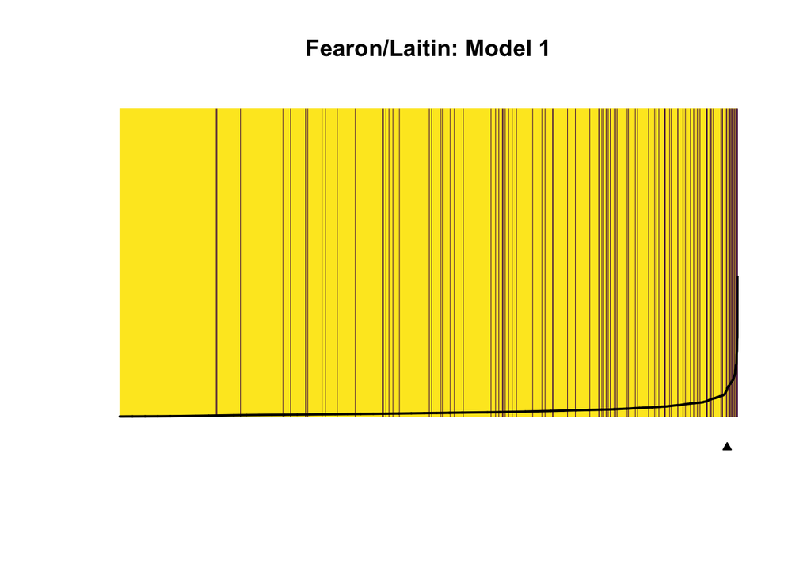

```r
separationplot(m_fearon1$fitted, m_fearon1$model$civilwar,
  line = TRUE,
  heading = "Fearon/Laitin: Model 1",
  show.expected = T,
  height = 2,
  col0 = viridis(2)[2],
  col1 = viridis(2)[1],
  lwd2 = 2,
  newplot = F
)
```

Again, we can also make classification tables and calculate the precentage of correctly predicted (aka accuracy) cases (PCP).

```r
class_table1 <-
  table(
    observed = factor(m_fearon1$model$civilwar, levels = 0:1),
    predicted = factor((m_fearon1$fitted.values > 0.5) * 1, levels = 0:1)
  )

pcp_1 <- sum(diag(class_table1)) / sum(class_table1)

pcp_1
## [1] 0.9832014
```

**Sounds pretty good, doesn’t it?**

But how good would a naive model - that is always predicting the majority class - predict civilwars?

That’s the so called Percent of observations in the Modal Category (PMC)

```r
table(m_fearon1$model$civilwar)
##
##    0    1
## 6087  104
max(table(m_fearon1$model$civilwar)) / sum(table(m_fearon1$model$civilwar))
## [1] 0.9832014
```

That’s exactly the same accuracy…

# Concluding Remarks

- In your homework you will further investigate the Fearon/Laitin models.

# Appendix

We can also make our life a little easier and write a function that will calculate the average case scenario for us:

```r
# m_fearon1$model contains the data used to estimate the model
# there are no missing data there, and the variables are in the same order as
# the main terms in the regression equation (but this is not as straightforward
# with models with interactions or cases where we pass character or factor vars
# into the model)
# the first column is the dependent variable
head(m_fearon1$model)
```

```
##   civilwar priorwar gdp_lagged log_population log_mountain noncontiguous oil
## 1        0        0      7.626       11.85630     3.214868             1   0
## 2        0        0      7.626       11.86313     3.214868             1   0
## 3        0        0      7.654       11.86859     3.214868             1   0
## 4        0        0      8.025       11.88673     3.214868             1   0
## 5        0        0      8.270       11.90488     3.214868             1   0
## 6        0        0      8.040       11.93343     3.214868             1   0
##   newstate instability democracy1 ethnicfrac relifrac
## 1        0           0         10  0.3569501    0.596
## 2        0           0         10  0.3569501    0.596
## 3        0           0         10  0.3569501    0.596
## 4        0           0         10  0.3569501    0.596
## 5        0           0         10  0.3569501    0.596
## 6        0           0         10  0.3569501    0.596
```

```r
average_case <- function(x, rep = 1) {
  # if there only two unique values in x and  difference between them is 1
  # (i.e. it is a dummy variable 0/1, 1/2 or similar)
  if (!is.numeric(x)) {
    return(paste0("Transform variable to numeric"))
  }
  if (length(unique(x)) == 2 & diff(range(x)) == 1) {
    # we take a median
    rep(median(x, na.rm = T), rep)
  } else {
    # otherwise, we take a mean
    rep(mean(x, na.rm = T), rep)
  }
}
# calculate the average for all independent variables
scenario <- cbind(1, apply(m_fearon1$model[, -1], 2, average_case, rep = 100))
# substitute the values in one variable with a sequence
scenario[, which(colnames(scenario) == "log_mountain")] <-
  seq(min(df$log_mountain, na.rm = T),
    max(df$log_mountain, na.rm = T),
    length.out = 100
  )
```

# References

Fearon, James D., and David D. Laitin. 2003. “Ethnicity, Insurgency, and Civil War.” *American Political Science Review* 97 (1): 75–90.

Greenhill, Brian, Michael D. Ward, and Audrey Sacks. 2011. “The Separation Plot: A New Visual Method for Evaluating the Fit of Binary Models.” *American Journal of Political Science* 55 (4): 991–1002.